# 5 Path Analysis 1

2020-12-05

## Path Analysis Part 1 Practice Assignment

In the section below, you should load the `lavaan` and `semPlot` libraries. The data correlation matrix is provided for you.

```r
library(lavaan)
library(semPlot)

academic.cor <- lav_matrix_lower2full(c(1,
                                        .178, 1,
                                        .230, .327, 1,
                                        .106, .245, .183, 1,
                                        .195, .356, .721, .178, 1))
rownames(academic.cor) <-
  colnames(academic.cor) <-
  c("race", "ses", "cog", "school", "acad")
```

## Build the Model

Use the following picture as your guide for building the path model. You can download this image online from Canvas. Be sure to save it in the same folder as your markdown file.

This model represents the relationship demographic variables (race, SES, school type), individual ability (cognitive ability) predicting academic achievement.

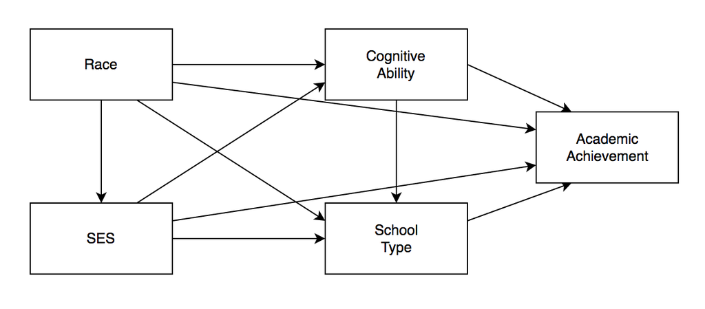

Create the `lavaan` model code in the code box below.

```r
model = "
acad ~ race + ses + cog + school
school ~ race + ses + cog
cog ~ race + ses
ses ~ race
"
```

## Analyze the Model

Analyze your path model using the `sem()` function. There are 18058 participants in the data.

```r
model.fit = sem(model, sample.cov = academic.cor, sample.nobs = 18058)
```

## Summarize Your Model

Use the `summary()` function to summarize your model.

```r
summary(model.fit, standardized = T)
```

```
## lavaan 0.6-7 ended normally after 16 iterations
##
##   Estimator                                         ML
##   Optimization method                           NLMINB
##   Number of free parameters                         14
##
##   Number of observations                         18058
##
## Model Test User Model:
##
##   Test statistic                                 0.000
##   Degrees of freedom                                 0
##
## Parameter Estimates:
##
##   Standard errors                             Standard
##   Information                                 Expected
##   Information saturated (h1) model          Structured
##
## Regressions:
##                    Estimate  Std.Err  z-value  P(>|z|)   Std.lv  Std.all
##   acad ~
##     race              0.015    0.005    2.935    0.003    0.015    0.015
##     ses               0.128    0.005   23.336    0.000    0.128    0.128
##     cog               0.671    0.005  122.482    0.000    0.671    0.671
##     school            0.022    0.005    4.191    0.000    0.022    0.022
##   school ~
##     race              0.046    0.007    6.151    0.000    0.046    0.046
##     ses               0.202    0.008   26.499    0.000    0.202    0.202
##     cog               0.106    0.008   13.804    0.000    0.106    0.106
##   cog ~
##     race              0.177    0.007   25.260    0.000    0.177    0.177
##     ses               0.295    0.007   42.061    0.000    0.295    0.295
##   ses ~
##     race              0.178    0.007   24.308    0.000    0.178    0.178
##
## Variances:
##                    Estimate  Std.Err  z-value  P(>|z|)   Std.lv  Std.all
##    .acad              0.463    0.005   95.021    0.000    0.463    0.463
##    .school            0.926    0.010   95.021    0.000    0.926    0.926
##    .cog               0.863    0.009   95.021    0.000    0.863    0.863
##    .ses               0.968    0.010   95.021    0.000    0.968    0.968
```

## Create a Picture

Use `semPaths()` to create a picture of your path model.

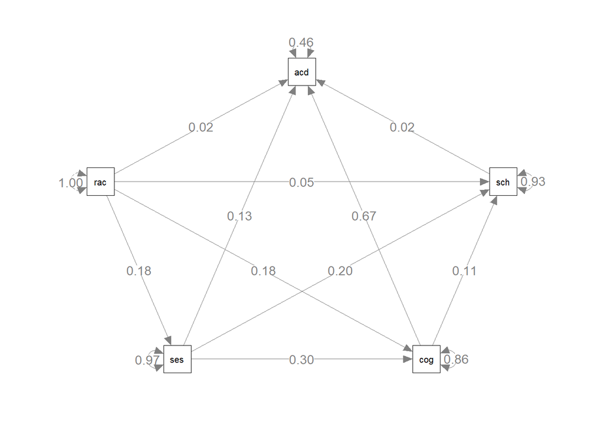

```r
semPaths(model.fit, whatLabels = "par", edge.label.cex = 1, layout = "spring")
```

## Mediation Models

For this example, you will create a mediation model with two indirect effects.

```r
mediation.cov <- lav_matrix_lower2full(c(84.85,
                                         71.28, 140.34,
                                         18.83, -6.25, 72.92,
                                         60.05, 84.54, 37.18, 139.48))
rownames(mediation.cov) <-
  colnames(mediation.cov) <- c("teacher", "social", "material", "achieve")
```

## Build the Model

Use the following image to create your mediation model. Note that you will have two indirect effects: one representing the top half of the model and one representing the bottom half of the model.

This model represents the mediating effects of social climate and the material covered in class on the relationship between teacher expectations and student achievement. The model predicts that teacher expectations actually predict social climate and materials, which then lead to student achievement levels if a mediating effect is found.

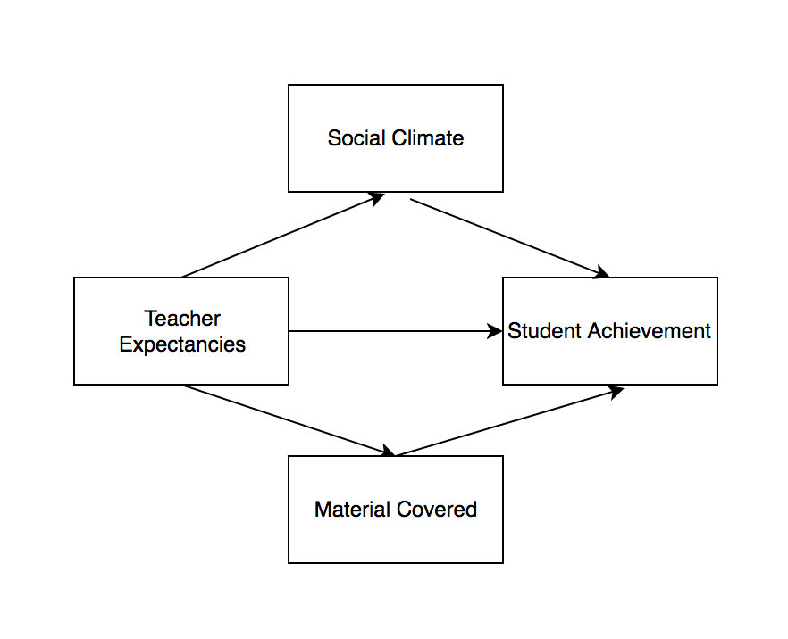

Path Model Picture

```r
model2 = "
achieve ~ a*teacher + b1*social + b2*material
social ~ a1*teacher
material ~ a2*teacher
indirect1 := a1*b1
indirect2 := a2*b2
"
```

## Analyze the Model

Analyze your path model using the `sem()` function. There are 40 participants in this data set.

```r
model2.fit = sem(model2, sample.cov = mediation.cov, sample.nobs = 40)
```

## Summarize Your Model

Use the `summary()` function to summarize your model.

```r
summary(model2.fit, standardized = T)
```

```
## lavaan 0.6-7 ended normally after 17 iterations
##
##   Estimator                                         ML
##   Optimization method                           NLMINB
##   Number of free parameters                          8
##
##   Number of observations                            40
##
## Model Test User Model:
##
##   Test statistic                                 3.687
##   Degrees of freedom                                 1
##   P-value (Chi-square)                           0.055
##
## Parameter Estimates:
##
##   Standard errors                             Standard
##   Information                                 Expected
##   Information saturated (h1) model          Structured
##
## Regressions:
##                    Estimate  Std.Err  z-value  P(>|z|)   Std.lv  Std.all
##   achieve ~
##     teacher    (a)    0.112    0.186    0.603    0.546    0.112    0.084
##     social    (b1)    0.569    0.142    4.006    0.000    0.569    0.545
##     material  (b2)    0.530    0.154    3.446    0.001    0.530    0.366
##   social ~
##     teacher   (a1)    0.840    0.154    5.456    0.000    0.840    0.653
##   material ~
##     teacher   (a2)    0.222    0.142    1.559    0.119    0.222    0.239
##
## Variances:
##                    Estimate  Std.Err  z-value  P(>|z|)   Std.lv  Std.all
##    .achieve          63.323   14.159    4.472    0.000   63.323    0.425
##    .social           78.448   17.542    4.472    0.000   78.448    0.573
##    .material         67.023   14.987    4.472    0.000   67.023    0.943
##
## Defined Parameters:
##                    Estimate  Std.Err  z-value  P(>|z|)   Std.lv  Std.all
##     indirect1         0.478    0.148    3.229    0.001    0.478    0.356
##     indirect2         0.118    0.083    1.421    0.155    0.118    0.088
```

## Create a Picture

Use `semPaths()` to create a picture of your path model.

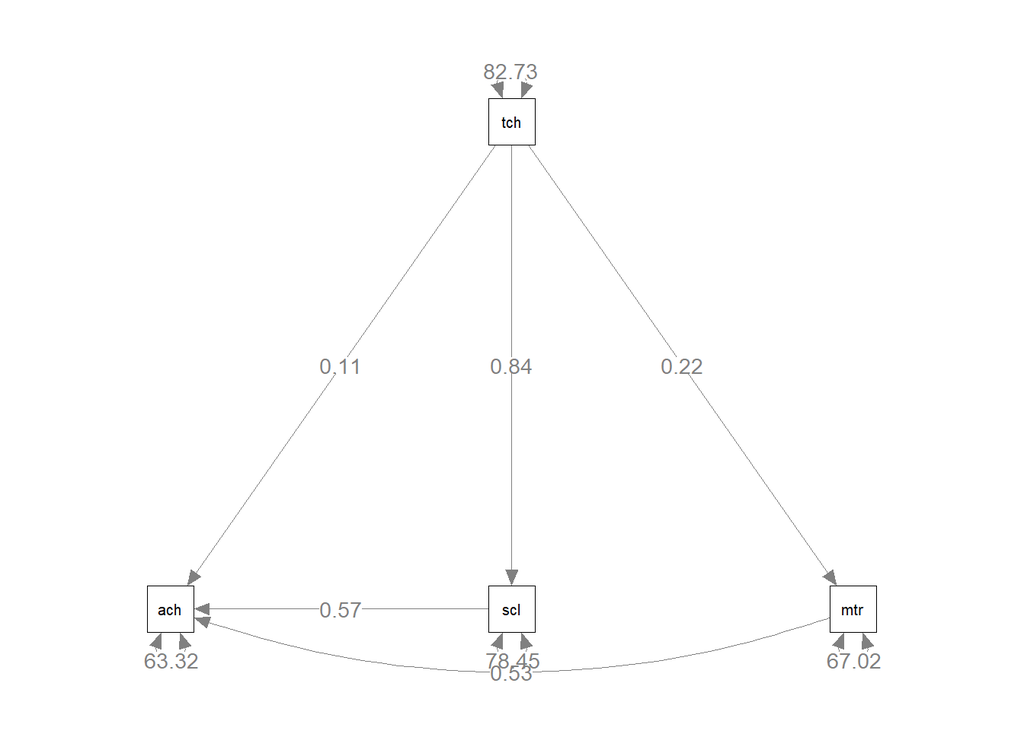

```r
semPaths(model2.fit, whatLabels = "par", edge.label.cex = 1, layout = "tree2")
```